PROVA 2 - Processos Estocásticos 2024.0

Ana Clara Valério - 202017764 e Natália Vieira - 190093811

07 fevereiro, 2024

## Questão 1

O objetivo do exercício é verificar a aplicabilidade de uma cadeia de Markov na modelagem de dados climáticos. Deverão ser utilizados os dados disponíveis na base “dados.txt” disponibilizado no SIGAA. Leia a base de dados no software R.

### (a) A partir da variável precipitação, crie um processo com espaço de estados contendo 5 elementos.

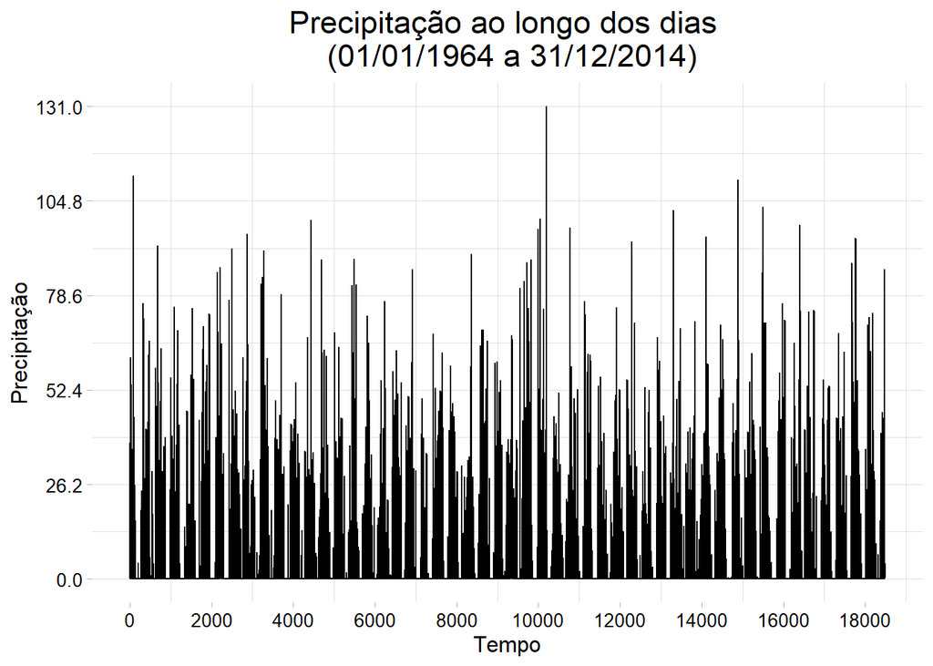

```r
dados <- read.delim("dados.txt", sep =";")[,-c(5,6,7)]
dados$Precipitacao <- as.numeric(dados$Precipitacao)
dados <- dados %>%
  na.omit() %>%
  mutate(Tempo = seq(1, 18480, 1))


ggplot(dados, aes(x= Tempo, y = Precipitacao, group = 1))+
  geom_line()+
  labs(title = "Precipitação ao longo dos dias \n (01/01/1964 a 31/12/2014)",
       y = "Precipitação",
       x = "Tempo")+
  scale_y_continuous(limits = c(0,131), breaks = seq(0,131,131/5))+
  scale_x_continuous(limits = c(0,18480), breaks = seq(0,18480,2000))+
  theme_light()+
  theme(axis.title.y=element_text(size=12),
        axis.title.x = element_text(size=12),
        axis.text = element_text(colour = "black", size=10),
        title = element_text(size = 14),
        plot.title = element_text(hjust = 0.5),
        panel.border = element_blank(),
        panel.grid.major.x = element_blank())
```

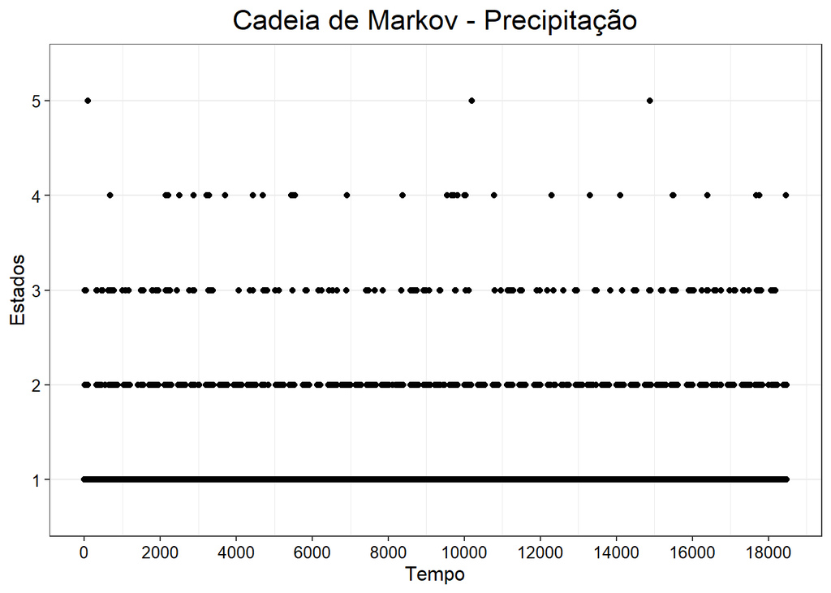

```r
elementos <- cut(dados$Precipitacao, breaks = 5, labels  = c("1","2","3","4","5"), levels = labels)

ggplot(data.frame(x = c(1:18480), y = elementos), aes(x=x, y=y)) +
  geom_point()+
  labs(title = "Cadeia de Markov - Precipitação",
       y = "Estados",
       x = "Tempo")+
  scale_x_continuous(limits = c(0,18480), breaks = seq(0,18480,2000))+
  theme_bw()+
  theme(axis.title.y=element_text(size=12),
        axis.title.x = element_text(size=12),
        axis.text = element_text(colour = "black", size=10),
        title = element_text(size = 14),
        plot.title = element_text(hjust = 0.5),
        panel.grid.major.x = element_blank())
```

A variável Precipitação é uma variável quantitativa contínua, por isso para definir os estados da cadeia de Markov categorizamos ela. Dividimos ela em 5 intervalos e cada um deles é um estado da nossa cadeia.

- Estado 1: (-0.131,26.2]
- Estado 2: (26.2, 52.4]
- Estado 3: (52.4,78.6]
- Estado 4: (78.6,105]
- Estado 5: (105,131]

### (b) Estime as probabilidades de transição com base nos dados (exceto para os últimos 10 dias que serão os dados de validação).

```r
estados <- head(elementos, n = 18470) # selecionando todos os dados, exceto os valores de precipitação para os últimos 10 dias

P1 <- createSequenceMatrix(estados)
P1
```

```
##       1   2   3  4 5
## 1 16867 587 129 29 3
## 2   592  64  12  3 0
## 3   126  15   5  1 0
## 4    28   4   1  0 0
## 5     2   1   0  0 0
```

```r
Fit = markovchainFit(data = estados,confidencelevel = 0.95)
round(Fit[["estimate"]]@transitionMatrix,2)
```

```
##      1    2    3    4 5
## 1 0.96 0.03 0.01 0.00 0
## 2 0.88 0.10 0.02 0.00 0
## 3 0.86 0.10 0.03 0.01 0
## 4 0.85 0.12 0.03 0.00 0
## 5 0.67 0.33 0.00 0.00 0
```

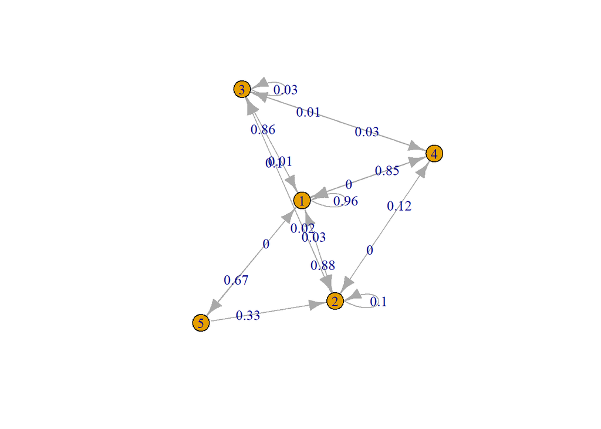

```r
mc = Fit$estimate
#summary(mc)

plot(mc)
```

### (c) Predizer os próximos símbolos do processo e avaliar a qualidade da estimação utilizando os 10 dias finais. (Dica: uma possibilidade é fazer uma matriz de confusão)

```r
(real <- as.vector(tail(estados, n=10)))
```

```
##  [1] "1" "1" "1" "1" "1" "4" "2" "1" "1" "1"
```

```r
(pred <- predict(mc,newdata = c("1","1"),n.ahead = 10))
```

```
##  [1] "1" "1" "1" "1" "1" "1" "1" "1" "1" "1"
```

```r
table(real, pred)
```

```
##     pred
## real 1
##    1 8
##    2 1
##    4 1
```

Como visto no item b, a probabilidade de transição do estado 1 para ele mesmo está muito elevada. Para tentar aproximar os valores preditos dos valores reais, fomos redefinindo as classes, trabalhando com classes menores nos valores iniciais e classes maiores nos valores maiores.

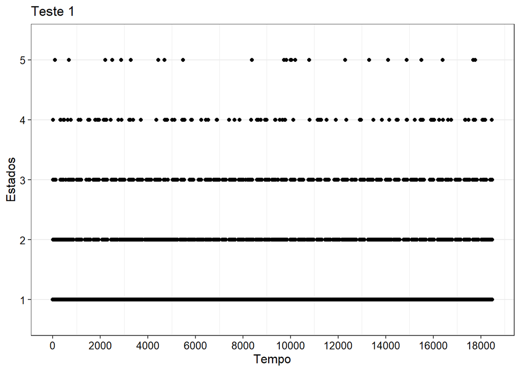

```r
# primeiro teste para classes diferentes
elementos <- cut(dados$Precipitacao, breaks = c(0,4,26,56,86,131), labels = c("1","2","3","4","5"),
                  levels = labels, include.lowest = T)
cm2 <- ggplot(data.frame(x = c(1:18480), y = elementos), aes(x=x, y=y)) +
  geom_point()+
  labs(y = "Estados",
       x = "Tempo",
       title = "Teste 1")+
  scale_x_continuous(limits = c(0,18480), breaks = seq(0,18480,2000))+
  theme_bw()+
  theme(axis.title.y=element_text(size=12),
        axis.title.x = element_text(size=12),
        axis.text = element_text(colour = "black", size=10),
        panel.grid.major.x = element_blank())

# segundo teste para classes diferentes
elementos <- cut(dados$Precipitacao, breaks = c(0,4,24,54,80,131),
                  labels = c("1","2","3","4","5"), levels = labels,
                  include.lowest = T)
cm3 <- ggplot(data.frame(x = c(1:18480), y = elementos), aes(x=x, y=y)) +
  geom_point()+
  labs(y = "Estados",
       x = "Tempo",
       title = "Teste 2")+
  scale_x_continuous(limits = c(0,18480), breaks = seq(0,18480,2000))+
  theme_bw()+
  theme(axis.title.y=element_text(size=12),
        axis.title.x = element_text(size=12),
        axis.text = element_text(colour = "black", size=10),
        panel.grid.major.x = element_blank())

# quarto e último teste para classes diferentes
elementos <- cut(dados$Precipitacao, breaks = c(0,3,23,43,73,131),
                  labels = c("1","2","3","4","5"), levels = labels,
                  include.lowest = T)

cm4 <- ggplot(data.frame(x = c(1:18480), y = elementos), aes(x=x, y=y)) +
  geom_point()+
  labs(y = "Estados",
       x = "Tempo",
       title = "Teste 3")+
  scale_x_continuous(limits = c(0,18480), breaks = seq(0,18480,2000))+
  theme_bw()+
  theme(axis.title.y=element_text(size=12),
        axis.title.x = element_text(size=12),
        axis.text = element_text(colour = "black", size=10),
        panel.grid.major.x = element_blank())

cm2
```

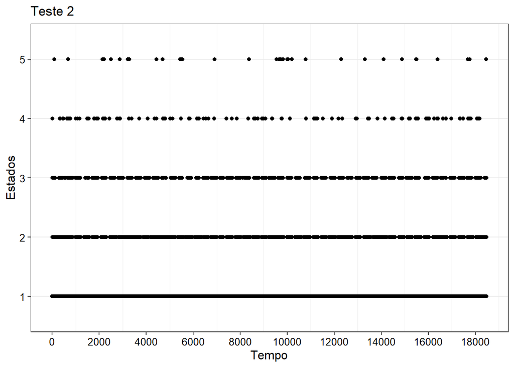

```r
cm3
```

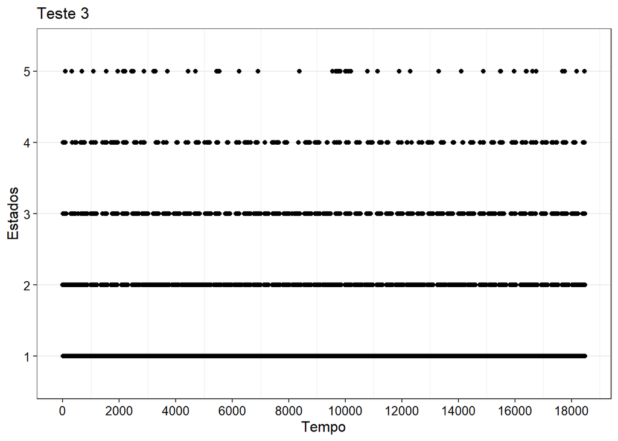

```r
cm4
```

Há uma sutil mudança entre os testes para definição de estados, então seguimos com o último apresentado em que cada estado engloba os seguintes intervalos/classes:

- Estado 1: [0,3];
- Estado 2: (3,23];
- Estado 3 (23,43]
- Estado 4: (43,73]
- Estado 5: (73,131]

```r
estados <- head(elementos, n = 18470) # pegando todos os dados, exceto os últimos 10 dias
P1 <- createSequenceMatrix(estados)
P1
```

```
##       1    2   3   4  5
## 1 11896 1742 379 109 32
## 2  1766 1142 259  95 16
## 3   366  278  76  17  5
## 4   103   97  25  11  1
## 5    28   18   3   5  0
```

```r
Fit = markovchainFit(data = estados,confidencelevel = 0.95)
round(Fit[["estimate"]]@transitionMatrix,2)
```

```
##      1    2    3    4    5
## 1 0.84 0.12 0.03 0.01 0.00
## 2 0.54 0.35 0.08 0.03 0.00
## 3 0.49 0.37 0.10 0.02 0.01
## 4 0.43 0.41 0.11 0.05 0.00
## 5 0.52 0.33 0.06 0.09 0.00
```

[figure not shown]

```r
plot(mc,  width = 12, height = 8)
```

As probabilidades nos primeiros estados continuam muito altas, mas prosseguimos obtendo o seguinte resultado.

```r
estados[c(18469,18470)]
```

```
## [1] 1 1
## Levels: 1 2 3 4 5
```

```r
(real <- as.vector(tail(estados, n=10)))
```

```
##  [1] "2" "2" "1" "2" "2" "5" "4" "2" "1" "1"
```

```r
(pred <- predict(mc,newdata = c("1","1"),n.ahead = 10))
```

```
##  [1] "1" "1" "1" "1" "1" "1" "1" "1" "1" "1"
```

```r
table(real, pred)
```

```
##     pred
## real 1
##    1 3
##    2 5
##    4 1
##    5 1
```

Vê-se que de 10 valores previstos, a cadeia utilizada só acertou 3 previsões. Considerando que os dois últimos dias pertenciam ao estado 1 e que a probabilidade de sair do estado 1 e chegar no estado 1 em um passo é de 84% aproximadamente, a probabilidade dos próximos dias terem precipitação de um valor que está dentro do intervalo do estado 1 é grande. Uma solução possível seria diminuir ainda mais os intervalos dos estados 1 e 2 e aumentar os do 3, 4 e 5.

## Questão 2

O objetivo dessa questão é a modelagem de ativos financeiros utilizando processos estocásticos a tempo contínuo. Para isso, um modelo teórico é assumido e comparado com o processo observado nos tempos t0 < t1 < · · · < tn. No software R, baixe a série de preços de fechamentos dos valores das ações do BBAS3 de 01/01/2023 a 31/12/2023. (Dica: utilize a função “quantmod::getSymbols”). Assuma que o preço das ações segue o modelo estocástico:

$$X(t) = X_0 - \theta \int_0^t X(s)ds +
\xi(t), \quad t \in [0, 1],$$
onde $X_0$ é o valor inicial do processo, $\theta \in (0,\infty)$ é um parâmetro (de drift) e $\{ \xi(t); t \in [0, 1] \}$ é um processo estocástico a tempo contínuo. Desejamos avaliar qual dos processos gera o melhor ajuste de modelo ao processo observado, o movimento Browniano $\xi(t) = B(t)$ ou o processo de Poisson $\xi(t) = N(t)$. Para isso, siga os seguintes passos:

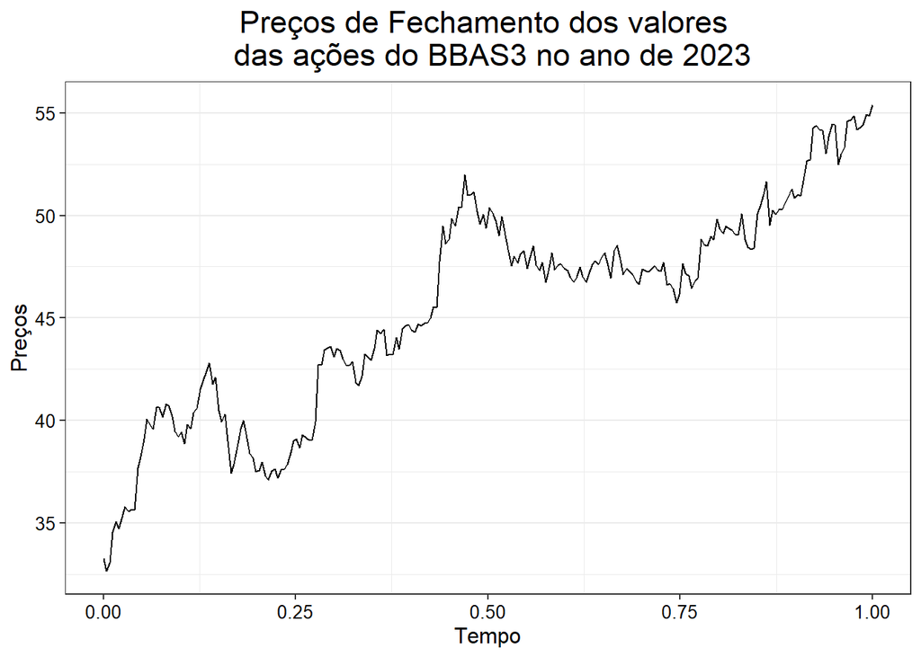

```r
BBAS3 <- as.data.frame(quantmod::getSymbols("BBAS3.SA", src = "yahoo", auto.assign = FALSE,
                                            from = '2023-01-01',
                                            to = '2023-12-31', return.class = 'xts')) %>%
  mutate(t = seq(0,1, length.out = 248))

BB=BBAS3$BBAS3.SA.Close %>% as.vector()

ggplot(BBAS3, aes(x = t, y = BBAS3.SA.Close))+
  geom_line()+
  labs(title = "Preços de Fechamento dos valores \n das ações do BBAS3 no ano de 2023",
       y = "Preços",
       x = "Tempo")+
  scale_x_continuous(limits = c(0,1))+
  theme_bw()+
  theme(axis.title.y=element_text(size=12),
        axis.title.x = element_text(size=12),
        axis.text = element_text(colour = "black", size=10),
        title = element_text(size = 14),
        plot.title = element_text(hjust = 0.5),
        panel.grid.major.x = element_blank())
```

### (a) Simule uma trajetória do movimento Browniano B = {B(t); t ∈ [0, 1]} e uma do processo de Poisson N = {N(t); t ∈ [0, 1]} com taxa λ = 1 contendo a mesma quantidade de pontos que a base de dados.

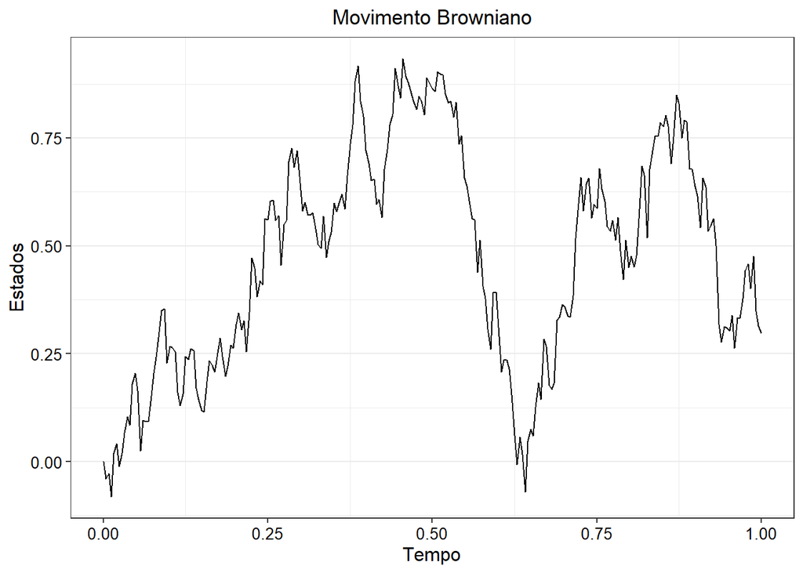

```r
# movimento browniano
simulatebrown <-  function(n,h) {
  times = (0:n)*h
  incrementos = (rnorm(n, 0, sd= sqrt(h)))
  B= c(0, cumsum(incrementos))
  return(list(mb = B, tempos= times))
}

set.seed(1)
a <- simulatebrown(n=248, h=1/248)

ggplot(data.frame(x = a$tempos, y = a$mb), aes(x=x, y=y)) +
  geom_line()+
  labs(y = "Estados",
       x = "Tempo",
       title = "Movimento Browniano")+
  scale_x_continuous(limits = c(0,1))+
  theme_bw()+
  theme(axis.title.y=element_text(size=12),
        axis.title.x = element_text(size=12),
        axis.text = element_text(colour = "black", size=10),
        plot.title = element_text(hjust = 0.5),
        panel.grid.major.x = element_blank())
```

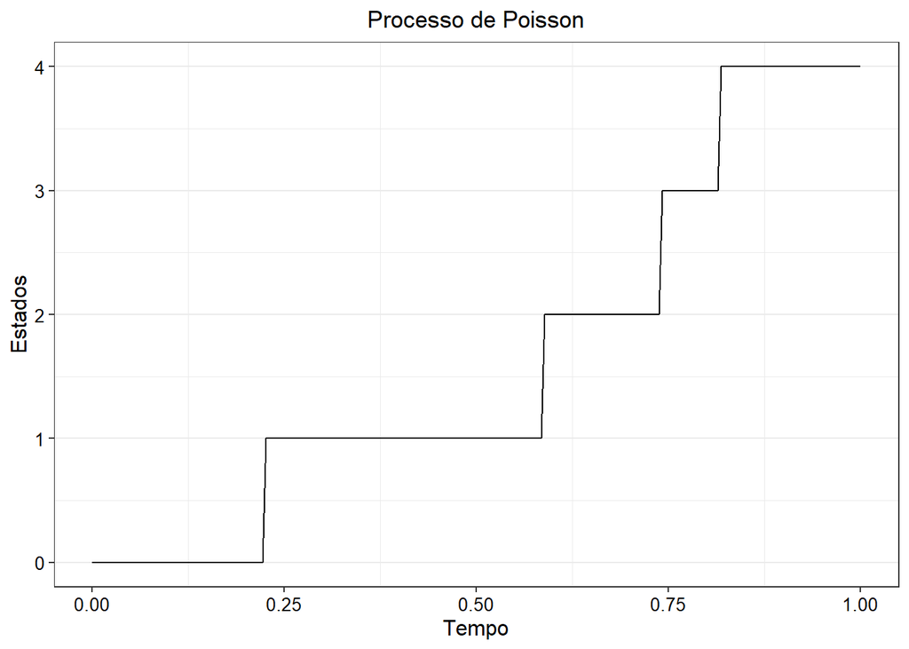

```r
# processo de poisson

incremento=1/248
tempos=seq(0,1,by=incremento)
n=length(tempos)
taxa=1

set.seed(24)
N=c(0,cumsum(rpois(n-1, lambda=taxa*incremento)))

ggplot(data.frame(x = tempos, y = N), aes(x=x, y=y)) +
  geom_line()+
  labs(y = "Estados",
       x = "Tempo",
       title = "Processo de Poisson")+
  scale_x_continuous(limits = c(0,1))+
  theme_bw()+
  theme(axis.title.y=element_text(size=12),
        axis.title.x = element_text(size=12),
        axis.text = element_text(colour = "black", size=10),
        plot.title = element_text(hjust = 0.5),
        panel.grid.major.x = element_blank())
```

### (b) Considere o processo discretizado

$$X(t_k) = X(t_{k-1}) - \theta
\sum_{j=0}^{k-1} X(t_j)(t_j - t_{j-1}) + \xi(t_k). \quad (1)$$

Programe uma função que receba os tempos $t_0 < \cdots < t_{k-1}$, o histórico do processo até o tempo $t_{k-1}$, ou seja, $(X(t_0), \ldots , X(t_{k-1}))$, um valor do parâmetro $\theta$ e o valor do processo $\xi(t_k)$. A saída da função deve ser o valor do processo no tempo $t_k$, ou seja, $X(t_k)$, calculado por (1).

```r
pdisc <- function(h, historico, taxa, processo){
  xtk <- numeric(length(historico))
  xtk[1] <- historico[1]
  for (k in 2:(n-1)) {
    xtk[k] <- xtk[k - 1] - taxa * h * sum(historico[1:(k - 1)]) + processo[k]
  }
  return(xtk)
}

head(pdisc(h= 1/248, historico = BB, taxa = 0.5, processo = rnorm(248)), 5) # testando se a função deu certo para o movimento browniano
```

```
## [1] 33.26000 33.78462 33.36342 32.63483 32.18575
```

```r
head(pdisc(h = 1/248, historico = BB, taxa = 0.5, processo = rpois(248,1)),5) # testando se a função deu certo para o processo de poisson
```

```
## [1] 33.26000 34.19294 36.06008 35.86056 36.59135
```

### (c) Estime o parâmetro θ a partir dos dados observados. (Dica: Um possível estimador é o de mínimos quadrados, comparando o processo observado ao modelo teórico (1). Nesse caso, são obtidos as estimativas θMB e θPP , respectivamente, para o movimento Browniano e o processo de Poisson).

```r
# Browniano e poisson, tem que ser definido no parâmetro tipo qual processo será usado.
# Caso seja utilizado o processo de Poisson, é necessário declarar o lambda,
# que por default será 1, já que estamos trabalhando
# com um processo de poisson com lambda > 0
processo_simulado <- function(theta, dado_observado, tipo = "Browniano", lambda=1) {
  n <- length(dado_observado)
  h <- 1/n
  tempo <- seq(0, 1, length.out = n)
  result <- numeric(n)
  if(tipo == "Browniano"){
    ruido = rnorm(248)
  }
  if(tipo == "Poisson"){
    ruido = rpois(248,lambda = lambda*(n*h))
  }
  for (k in 2:n) {
    result[k] <- result[k - 1] - theta * sum(dado_observado[1:(k - 1)] * h) + ruido[k]
  }
  return(result)
}

# Função para calcular a soma dos quadrados dos resíduos
soma_de_quadrados <- function(theta, dado_observado, tipo = "Browniano", lambda=1) {
  modelo_simulado <- processo_simulado(theta, dado_observado, tipo, lambda=1)
  residuals <- dado_observado - modelo_simulado
  return(sum(residuals^2))
}
```

```r
# Estimação do parâmetro theta para o Movimento Browniano
set.seed(1)
theta_chapeu_MB <- optimize(f = soma_de_quadrados,
                            interval = c(0, 1e6),
                         dado_observado = as.numeric(BB),
                         tol = .01)$minimum

# Estimação do parâmetro theta para o Processo Poisson
set.seed(1)
theta_chapeu_PP <- optimize(f = soma_de_quadrados,
                            interval = c(0, 1e6),
                            dado_observado = as.numeric(BB),
                            tipo = "Poisson", lambda=1,
                            tol = .01)$minimum

theta_chapeu_MB # movimento browniano
```

```
## [1] 0.006087756
```

```r
theta_chapeu_PP # processo poisson
```

```
## [1] 0.04072724
```

Obtivemos os seguintes valores, considerando uma acurácia de 1%: $\theta_{MB} = 0.006087756$ e $\theta_{PP} = 0.04072724$

### (d) Avalie os resíduos (diferença entre processo observado e modelo ajustado) do ajuste. (Dica: podem ser feitos testes de normalidade dos resíduos, histograma, boxplot e/ou Normal-qq plot).

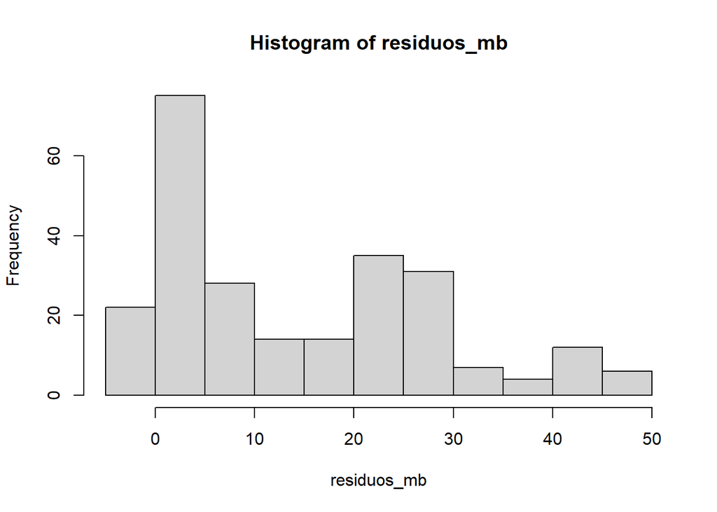

```r
set.seed(1)
x_simulado_mb <- pdisc(h=1/248, historico = BB, taxa = theta_chapeu_MB, processo = rnorm(248))
residuos_mb <- BB - x_simulado_mb
hist(residuos_mb)
```

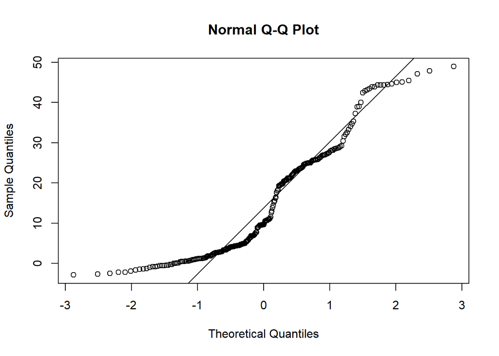

```r
qqnorm(residuos_mb)
qqline(residuos_mb)
```

```r
shapiro.test(residuos_mb)
```

```
##
##  Shapiro-Wilk normality test
##
## data:  residuos_mb
## W = 0.90052, p-value = 9.657e-12
```

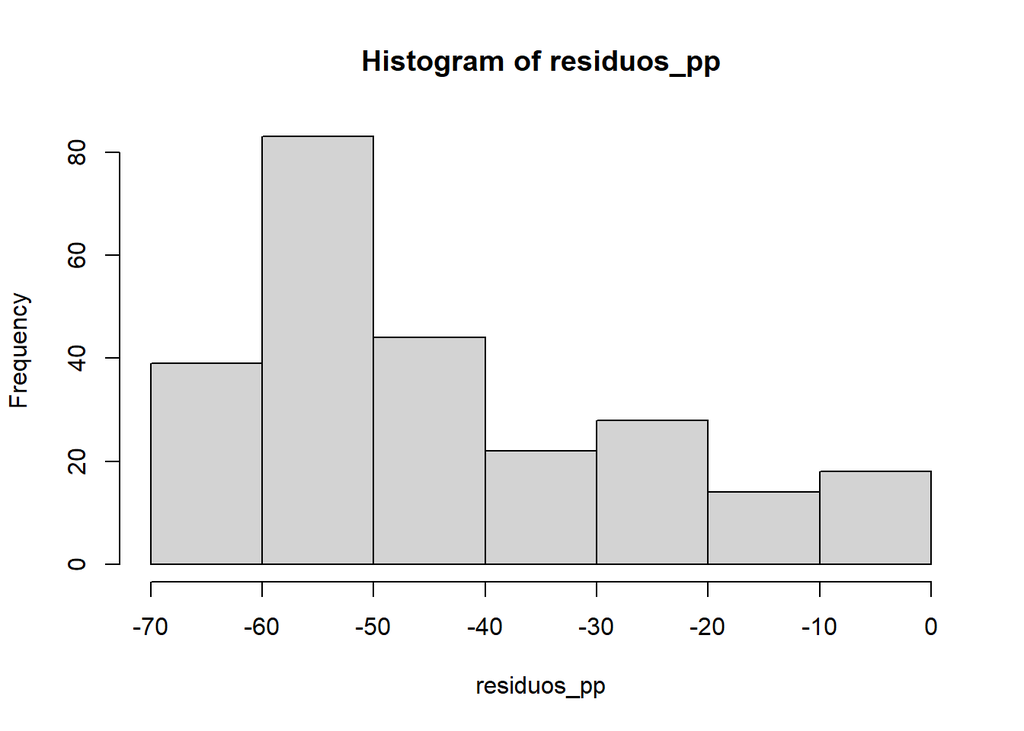

```r
set.seed(1)
x_simulado_pp <- pdisc(h=1/248, historico = BB, taxa = theta_chapeu_PP, processo = rpois(248,1))
residuos_pp <- BB - x_simulado_pp
hist(residuos_pp)
```

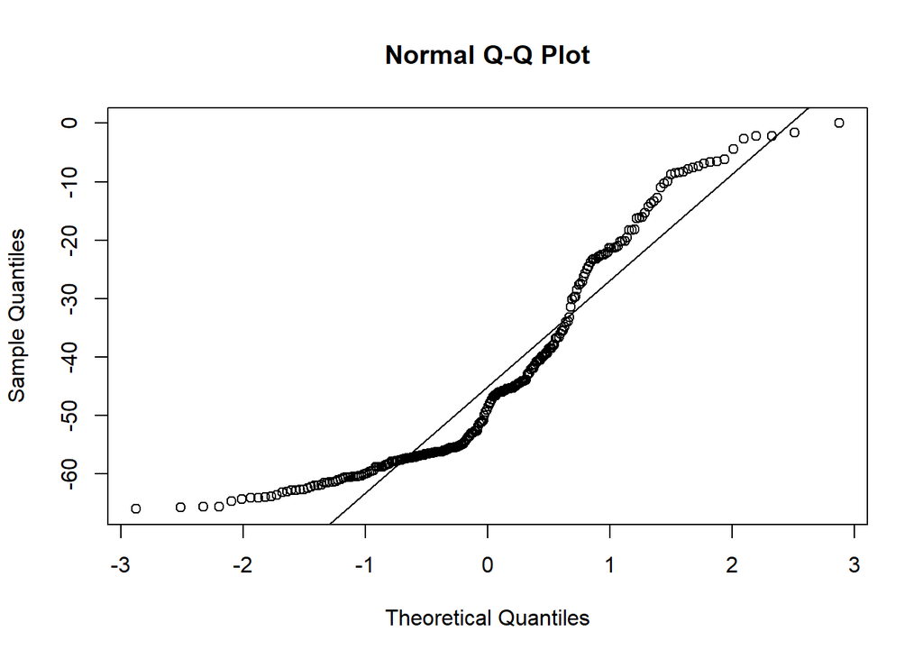

```r
qqnorm(residuos_pp)
qqline(residuos_pp)
```

```r
shapiro.test(residuos_pp)
```

```
##
##  Shapiro-Wilk normality test
##
## data:  residuos_pp
## W = 0.8851, p-value = 9.187e-13
```

É possível observar que tanto o processo simulado para o Movimento Browniano quanto o Processo de Poisson os resíduos rejeitam normalidade, considerando um $\alpha = 0.01$, embora o p-valor dos resíduos do modelo de poisson seja um pouco menor que o browniano.

### (e) Represente graficamente o processo observado e os modelos ajustados.

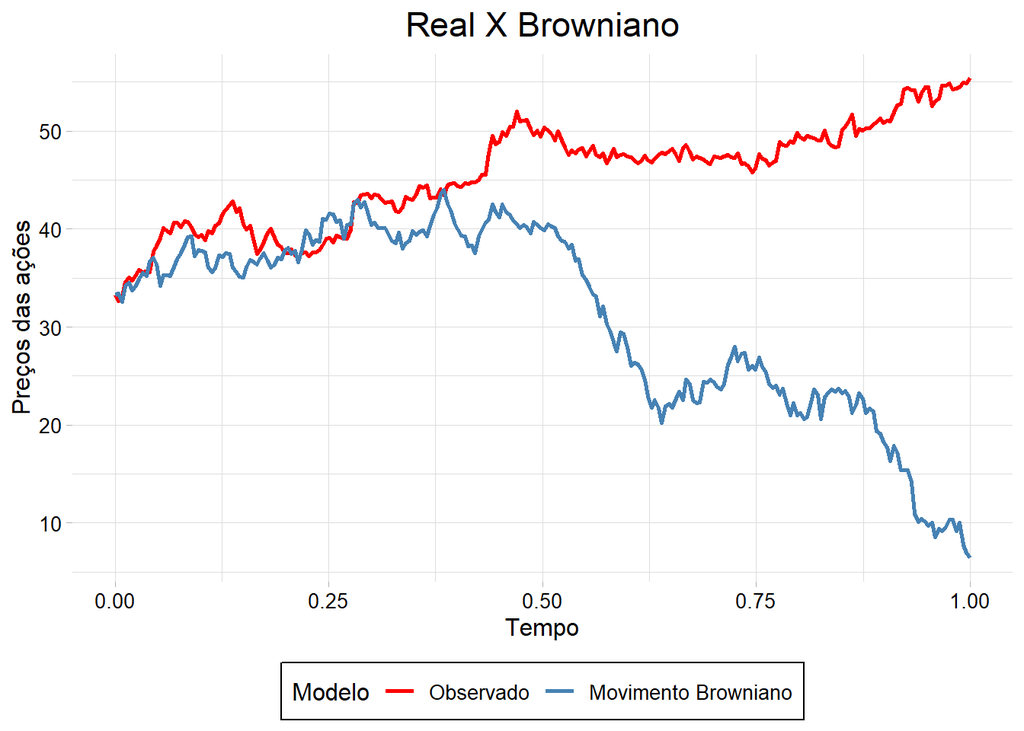

```r
processos <- data.frame(indice = seq(0, 1, length.out= (248)),
                        acoes = BB,
                        MB = x_simulado_mb,
                        PP = x_simulado_pp)

processos <- processos %>% pivot_longer(!indice, names_to = "Modelo", values_to = "Processos")
ppoisson <- processos %>% filter(Modelo != "MB")
pbrown <- processos %>% filter(Modelo != "PP")

g1 <- ggplot(data = pbrown, aes(x = indice, y= Processos, color = Modelo, group = Modelo)) +
    geom_line(size = 1)+
    scale_color_manual(values = c("acoes" = "red", "MB" = "#4682B4"),
                     labels = c("acoes" = "Observado", "MB" = "Movimento Browniano"))+
    labs(title = "Real X Browniano",
         y = "Preços das ações",
         x = "Tempo")+
    #ylim(30, 60)+
    theme_light()+
    theme(axis.title.y=element_text(size=12),
          axis.title.x = element_text(size=12),
          axis.text = element_text(colour = "black", size=10),
          title = element_text(size = 14),
          plot.title = element_text(hjust = 0.5),
          panel.border = element_blank(),
          legend.position = "bottom",
          legend.background = element_rect(colour = "black"),
          legend.title = element_text(size = 12),
          legend.text = element_text(size = 10))


g2 <- ggplot(data = ppoisson, aes(x = indice, y= Processos, color = Modelo, group = Modelo)) +
    geom_line(size = 1)+
    scale_color_manual(values = c("acoes" = "red", "PP" = "#2E8B57"),
                       labels = c("acoes" = "Observado", "PP" = "Processo de Poisson"))+
    labs(title = "Real X Poisson",
         y = "Preços das ações",
         x = "Tempo")+
    #ylim(30, 60)+
    theme_light()+
    theme(axis.title.y=element_text(size=12),
          axis.title.x = element_text(size=12),
          axis.text = element_text(colour = "black", size=10),
          title = element_text(size = 14),
          plot.title = element_text(hjust = 0.5),
          panel.border = element_blank(),
          legend.position = "bottom",
          legend.background = element_rect(colour = "black"),
          legend.title = element_text(size = 12),
          legend.text = element_text(size = 10))


g1
```

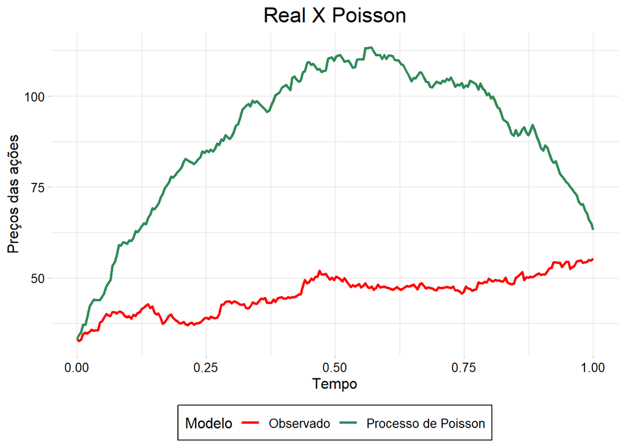

```r
g2
```

O modelo Browniano até o momento 0.5 possui valores próximos do modelo observado, principalmente nos tempos iniciais. Já o modelo de Poisson parece se aproximar somente no instante 0. Sendo assim, uma primeira hipótese seria que o modelo Browniano se adequa melhor ao modelo observado.

### (f) Estabeleça qual o melhor modelo (utilizando movimento Browniano ou processo de Poisson).

```r
# Calculando o erro quadrático médio (EQM) para cada modelo
eqm_mb <- mean(residuos_mb^2)
eqm_pp <- mean(residuos_pp^2)

eqm_mb
```

```
## [1] 398.6386
```

```r
eqm_pp
```

```
## [1] 2223.269
```

```r
eqm_mb < eqm_pp
```

```
## [1] TRUE
```

Para estabeler o melhor modelo, foi realizada uma comparação entre os erros quadráticos médios de cada um, além de já ter sido realizado na (d) uma análise do resíduos. Como o EQM do Processo de Poisson deu maior que o do Movimento Browniano, então conclui-se que o modelo Browniano é melhor para os dados observados.

### (g) Leia os dados de 01/01/2024 a 15/01/2024. Utilize o modelo ajustado em (c) para predizer o valor das novas observações com base nos dados de 2023. Analise os resultados.

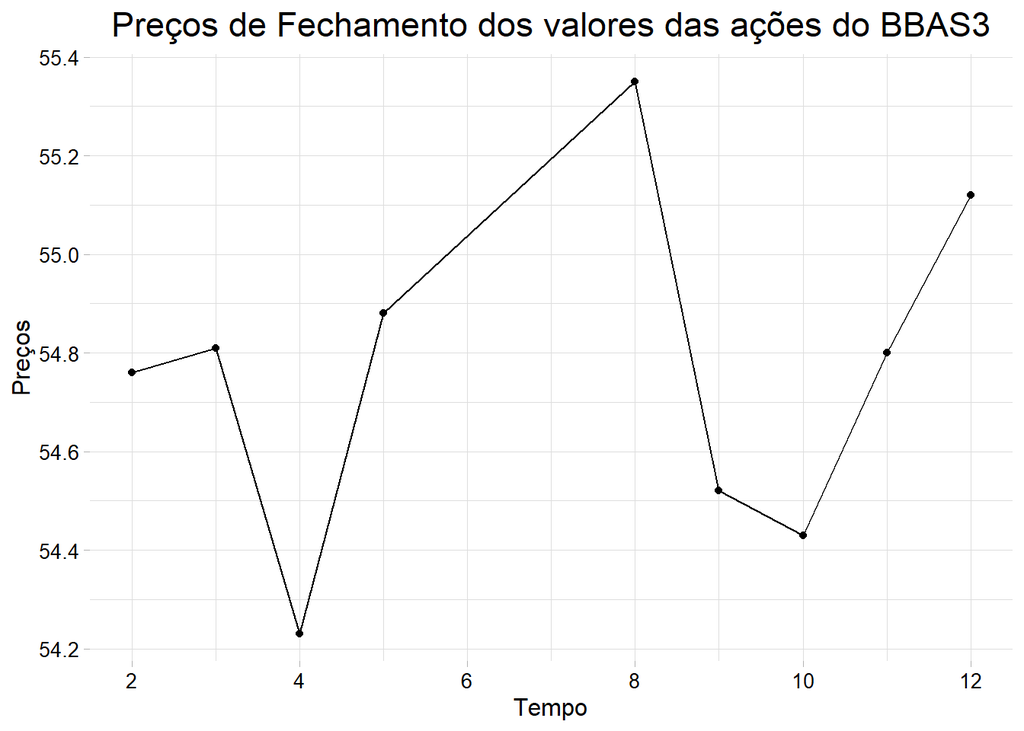

```r
BB24 <- as.data.frame(quantmod::getSymbols("BBAS3.SA", src = "yahoo", auto.assign = FALSE,
                                            from = '2024-01-01',
                                            to = '2024-01-15', return.class = 'xts')) %>%
  mutate(dias = c(2,3,4,5,8,9,10,11,12))

fechamento <- BB24$BBAS3.SA.Close %>% as.vector()

ggplot(BB24, aes(x= dias, y = BBAS3.SA.Close))+
  geom_line()+
  geom_point()+
  labs(title = "Preços de Fechamento dos valores das ações do BBAS3",
       y = "Preços",
       x = "Tempo")+
  scale_x_continuous(limits = c(2,12), breaks = seq(2,12,2))+
  theme_light()+
  theme(axis.title.y=element_text(size=12),
        axis.title.x = element_text(size=12),
        axis.text = element_text(colour = "black", size=10),
        title = element_text(size = 14),
        plot.title = element_text(hjust = 0.5),
        panel.border = element_blank(),
        legend.position = "bottom",
        legend.background = element_rect(colour = "black"),
        legend.title = element_text(size = 12),
        legend.text = element_text(size = 10))
```

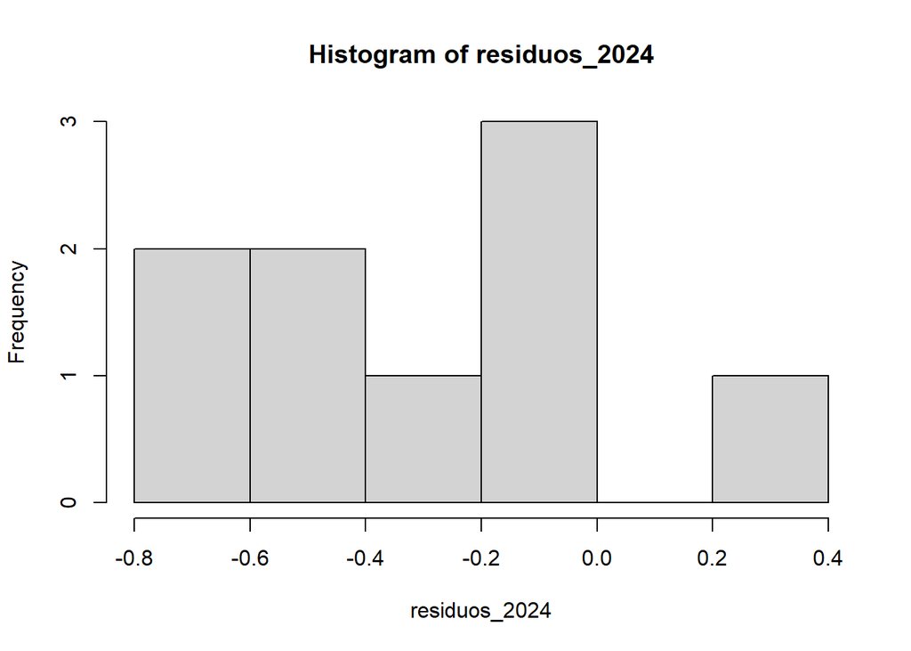

```r
set.seed(1)
mb2024 <- (pdisc(h=1/9, historico = fechamento,
                taxa = theta_chapeu_MB,
                processo = rnorm(9)))[1:9]
residuos_2024 <- fechamento - mb2024
hist(residuos_2024)
```

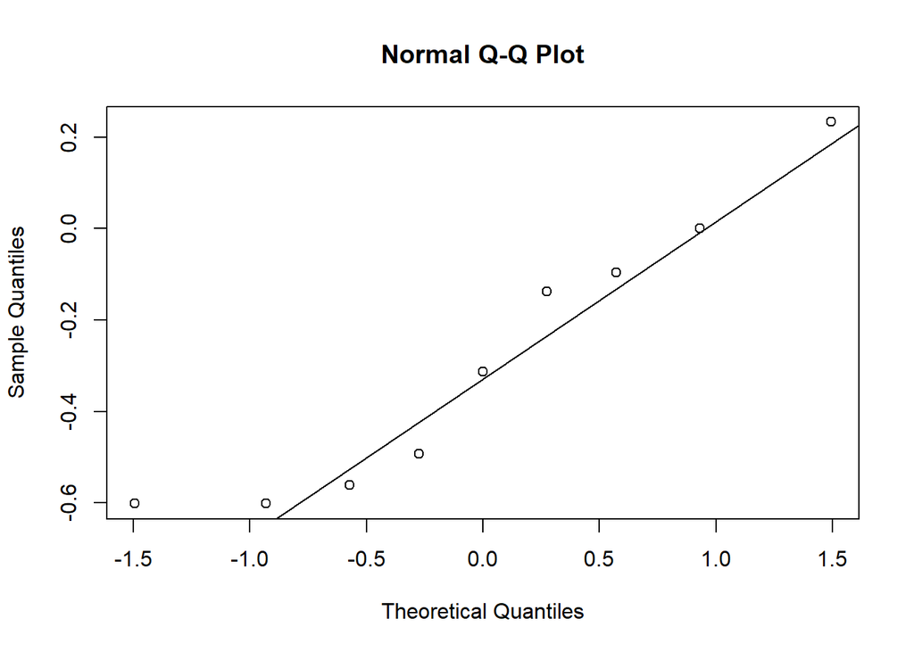

```r
qqnorm(residuos_2024)
qqline(residuos_2024)
```

```r
shapiro.test(residuos_2024)
```

```
##
##  Shapiro-Wilk normality test
##
## data:  residuos_2024
## W = 0.90694, p-value = 0.295
```

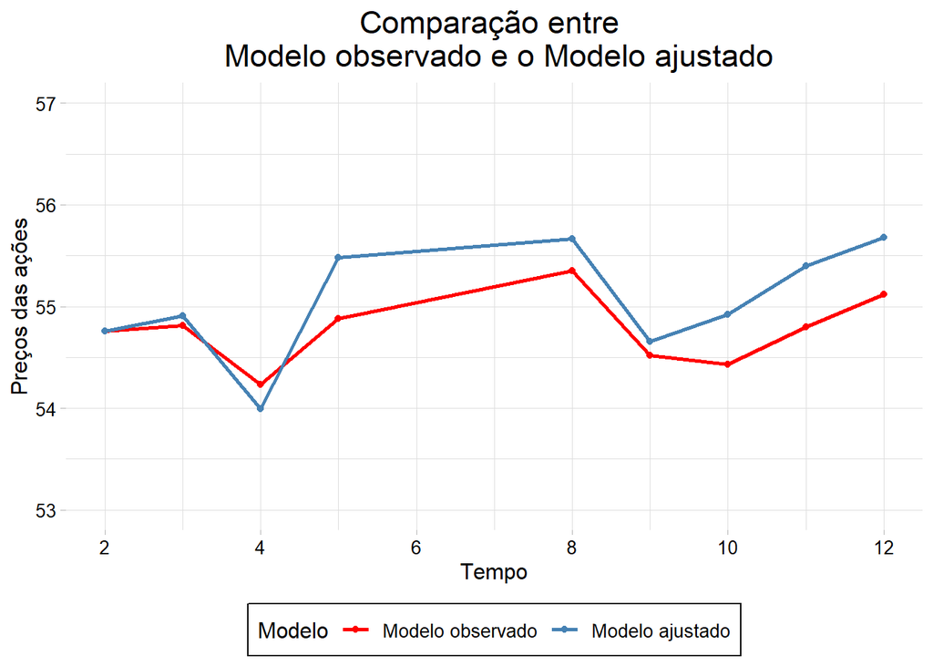

```r
acoes24 <- data.frame(indice = c(2,3,4,5,8,9,10,11,12),
                      acoes = fechamento,
                      MB = mb2024)

acoes24 <- acoes24 %>% pivot_longer(!indice, names_to = "Modelo", values_to = "Processos")

ggplot(data = acoes24, aes(x = indice, y= Processos, color = Modelo, group = Modelo)) +
    geom_line(size = 1)+
    geom_point(size = 1.5)+
    scale_color_manual(values = c("acoes" = "red", "MB" = "#4682B4"),
                     labels = c("acoes" = "Modelo observado", "MB" = "Modelo ajustado"))+
    labs(title = "Comparação entre \n Modelo observado e o Modelo ajustado",
         y = "Preços das ações",
         x = "Tempo")+
    scale_x_continuous(limits = c(2,12), breaks=seq(2,12,2))+
    scale_y_continuous(limits = c(53,57), breaks = c(53:57))+
    theme_light()+
    theme(axis.title.y=element_text(size=12),
          axis.title.x = element_text(size=12),
          axis.text = element_text(colour = "black", size=10),
          title = element_text(size = 14),
          plot.title = element_text(hjust = 0.5),
          panel.border = element_blank(),
          legend.position = "bottom",
          legend.background = element_rect(colour = "black"),
          legend.title = element_text(size = 12),
          legend.text = element_text(size = 10))
```